# Installing R packages

Claudius Gräbner-Radkowitsch

2022-09-06

# 1 Installing R packages

After installing R and R-Studio, you still need to install a number of so called [R packages](https://r-pkgs.org/). We will learn more about what packages are and how to use them later. Nevertheless, I strongly recommend you to install already all the packages you will need over the following semester already now. This way you make sure that everything is working now, and you save yourself from trouble during the semester. Moreover, installing these packages is necessary to do the exercises provided after each session.

To install packages, a stable internet connection is required. Then, proceed as follows:

1. Download the script install_packages_script.R and save it in a directory of your choice
2. Open the file `install_packages_script.R` in R-Studio. To this end, right-click on the file and select `Open with`, and then choose R-Studio.
3. Adjust the first line of the script to the OS you are using. For instance, when you are using a Mac the file should look like this:

[figure not shown]

[figure not shown]

4. Select lines 1-37 and click on the button `Run` (the screenshot only shows the lines 24-37, the previous lines are also selected):

[figure not shown]

5. Check if the package `here` was installed. You will get the respective message in the console:

[figure not shown]

If you encounter any problems, please make a screenshot and post it in the Moodle forum. 6. Select the rest of the scrip and run it as you did with the first lines. If you get the following message everything worked well and all packages were installed successfully:

[figure not shown]

If not, please post the file `InstallationLog.txt` and a screenshot with an error into the Moodle forum.

Note: maybe you will see the following message during the installation process (possible multiple times):

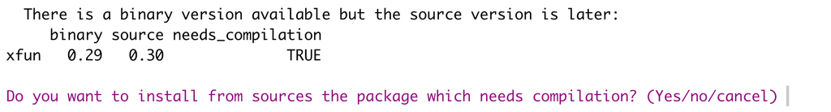

I recommend to type `No` and press enter. If, for any reason, the installation process is not successful you might run the installation commands again and try responding with `Yes`, this might sometimes fix the problem.

# 2 Verify the usability of exercises

If everything worked well until here you should be able to access the exercise sheets that I provide you with after each session. To make sure everything works as expected, please run the following command in the console and press enter:

```r
learnr::run_tutorial(
  name = "Basics",
  package = "DataScienceExercises",
  shiny_args=list("launch.browser"=TRUE))
```

This means you type it like this and press enter:

[figure not shown]

If the exercise window opens, everything is well, if not, please describe your problem in the Moodle forum.

After you closed the window and the process is still active, just click on the `Stop` button in R-Studio:

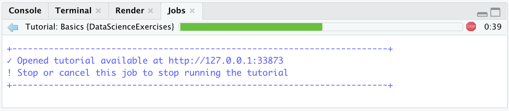

And then click on the `Console` tab on the left to return to the console.

# 3 Installing LaTeX

To create PDF-documents you have to install a [Latex distribution](https://www.latex-project.org/). I recommend you to install the distribution [tinytex](https://yihui.org/tinytex/), no matter whether you already have a different distribution or not.

In the previous step you already installed the *package* `tinytex`. This is *not* the distribution. To install the latter, you need to execute the following commands while having a stable internet connection:

```r
tinytex::install_tinytex()
```

To make sure everything runs smoothly you should download the document test_pdf.Rmd. To test whether everything works, please open `test.Rmd` in R-Studio and then click on the button `Knit to PDF`:

[figure not shown]

If this works you are all set. If there are any errors showing up, please post a screenshot and a problem description to the Moodle forum.

## 3.1 A common problem when installing tinytex on a Mac

The following hints should be helpful if after the attempted installation of `tinytex` you see either one of these error messages:

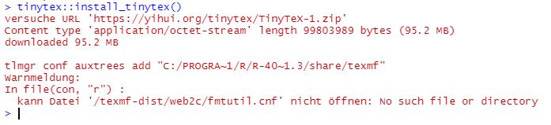

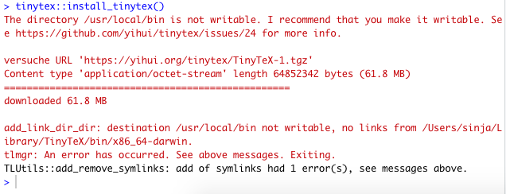

In this case, execute the following comment in your R console within R-Studio:

```r
tinytex::install_tinytex(force = TRUE)
```

Then close R-Studio and restart your computer. If `test.Rmd` still cannot be compiled after this, please open your Mac Terminal (via the app `Terminal`) and enter the following commands:

```
sudo chown -R `whoami`:admin /usr/local/bin

~/Library/TinyTeX/bin/x86_64-darwin/tlmgr path add
```

Then install `tinytex` again as described above, restart your computer, and try to compile `test.Rmd` again.